# R Notebook

```r
library(tidyverse)
library(tidytuesdayR)
library(lubridate)
```

```r
count_NA_in_df = function(df){
  df %>%
    map(~ sum(is.na(.x))) %>%
    as_tibble()
}


var_summary_stats <- function(column, na.rm = TRUE) {
  # the argument column is expected to be numeric vector, as this function was designed
  # to work with purrr::map (which passes dataframe columns as vectors to the function
  # being mapped)

  # return a single row dataframe containing the summary stats for column
  tibble(
    n = sum(!is.na(column)),
    min = min(column, na.rm = na.rm),
    q1 = quantile(column, probs = 0.25, na.rm = na.rm),
    median = median(column, na.rm = na.rm),
    q3 = quantile(column, probs = 0.75, na.rm = na.rm),
    max = max(column, na.rm = na.rm),
    iqr = IQR(column, na.rm = na.rm),
    mean = mean(column, na.rm = na.rm),
    sd = sd(column, na.rm = na.rm)
  )
}

df_summary_stats <- function(df){

  # get the names of the numeric variables in the dataframe
  variable_name <- df %>%
    select_if(is.numeric) %>%
    names()

  # return a dataframe containing summary stats for each numeric variable in df
  df %>%
    select_if(is.numeric) %>%
    purrr::map_dfr(var_summary_stats) %>%
    add_column(variable_name, .before = 1)
}

`%nin%` = Negate(`%in%`)
```

```r
count_NA_in_df = function(df){
  df %>%
    map(~ sum(is.na(.x))) %>%
    as_tibble()
}


var_summary_stats <- function(column, na.rm = TRUE) {
  # the argument column is expected to be numeric vector, as this function was designed
  # to work with purrr::map (which passes dataframe columns as vectors to the function
  # being mapped)

  # return a single row dataframe containing the summary stats for column
  tibble(
    n = sum(!is.na(column)),
    min = min(column, na.rm = na.rm),
    q1 = quantile(column, probs = 0.25, na.rm = na.rm),
    median = median(column, na.rm = na.rm),
    q3 = quantile(column, probs = 0.75, na.rm = na.rm),
    max = max(column, na.rm = na.rm),
    iqr = IQR(column, na.rm = na.rm),
    mean = mean(column, na.rm = na.rm),
    sd = sd(column, na.rm = na.rm)
  )
}

df_summary_stats <- function(df){

  # get the names of the numeric variables in the dataframe
  variable_name <- df %>%
    select_if(is.numeric) %>%
    names()

  # return a dataframe containing summary stats for each numeric variable in df
  df %>%
    select_if(is.numeric) %>%
    purrr::map_dfr(var_summary_stats) %>%
    add_column(variable_name, .before = 1)
}

`%nin%` = Negate(`%in%`)
```

## Tidy data

check types - `commissioning_date` as character, all other types look ok at first glance.

Errors when try to coerce `commissioning_date` to a numeric, as the column includes up to three commissioning dates (e.g. 2005/2006/2012)

```r
# Argument for parsing commisioning date as a double, which throw parsing errors -
# col_types = cols(commissioning_date = col_double())
wind_turbine <- readr::read_csv('https://raw.githubusercontent.com/rfordatascience/tidytuesday/master/data/2020/2020-10-27/wind-turbine.csv')
wind_turbine
```

| objectid | province_territory | project_name | total_project_capacity_mw | turbine_identifier | turbine_number_in_project | turbine_rated_capacity_k_w | rotor_diameter_m | hub_height_m | manufacturer | model | commissioning_date | latitude | longitude | notes |
| --- | --- | --- | --- | --- | --- | --- | --- | --- | --- | --- | --- | --- | --- | --- |
| 1 | Alberta | Optimist Wind Energy | 0.90 | OWE1 | 1/2 | 150 | 23.0 | 30 | Bonus | AN 150/30 | 1993 | 49.52535 | -114.0548 | NA |
| 2 | Alberta | Castle River Wind Farm | 44.00 | CRW1 | 1/60 | 600 | 44.0 | 40 | Vestas | V44/600 | 1997 | 49.51264 | -114.0357 | NA |
| 3 | Alberta | Waterton Wind Turbines | 3.78 | WWT1 | 1/6 | 600 | 44.0 | 50 | Vestas | V44/600 | 1998 | 49.23307 | -113.6549 | NA |
| 4 | Alberta | Waterton Wind Turbines | 3.78 | WWT2 | 2/6 | 600 | 44.0 | 50 | Vestas | V44/600 | 1998 | 49.23303 | -113.6302 | NA |
| 5 | Alberta | Waterton Wind Turbines | 3.78 | WWT3 | 3/6 | 600 | 44.0 | 50 | Vestas | V44/600 | 1998 | 49.21755 | -113.6802 | NA |
| 6 | Alberta | Waterton Wind Turbines | 3.78 | WWT4 | 4/6 | 660 | 47.0 | 50 | Vestas | V47/660 | 2000 | 49.21773 | -113.6579 | NA |
| 7 | Alberta | Cowley North | 19.50 | CON1 | 1/15 | 1300 | 60.0 | 46 | Nordex | N60/1300 | 2001 | 49.56876 | -114.1104 | NA |
| 8 | Alberta | Cowley North | 19.50 | CON2 | 2/15 | 1300 | 60.0 | 46 | Nordex | N60/1300 | 2001 | 49.56788 | -114.1097 | NA |
| 9 | Alberta | Cowley North | 19.50 | CON3 | 3/15 | 1300 | 60.0 | 46 | Nordex | N60/1300 | 2001 | 49.56696 | -114.1103 | NA |
| 10 | Alberta | Cowley North | 19.50 | CON4 | 4/15 | 1300 | 60.0 | 46 | Nordex | N60/1300 | 2001 | 49.56597 | -114.1105 | NA |

[output cut: 990 more lines]

```r
NA
NA
```

So, separate the strings for commissioned data into upto three variables (`com_date_1`, `com_date_2`, `com_date_3`) and then coerce these from characters to numerics

```r
wind_turbine %>%
  distinct(commissioning_date)
```

| commissioning_date |
| --- |
| 1993 |
| 1997 |
| 1998 |
| 2000 |
| 2001 |
| 2002 |
| 2003 |
| 2004 |
| 2006 |
| 2007 |

[output cut: 25 more lines]

Hoping to get some interesting information about lifespans of turbines (where multiple commissioning dates where provided in the dataset), but little interesting or useful information in here.

```r
wind_turbine <- wind_turbine %>%
  separate(commissioning_date, sep = "/", into = c("com_date_1", "com_date_2", "com_date_3")) %>%
  mutate(com_date_1 = as.numeric(com_date_1),
         com_date_2 = as.numeric(com_date_2),
         com_date_3 = as.numeric(com_date_3),
         most_recent_com_date = pmax(com_date_1, com_date_2, com_date_3, na.rm = TRUE)
         )
```

```
Expected 3 pieces. Missing pieces filled with `NA` in 6625 rows [1, 2, 3, 4, 5, 6, 7, 8, 9, 10, 11, 12, 13, 14, 15, 16, 17, 18, 19, 20, ...].
```

```r
wind_turbine
```

| objectid | province_territory | project_name | total_project_capacity_mw | turbine_identifier | turbine_number_in_project | turbine_rated_capacity_k_w | rotor_diameter_m | hub_height_m | manufacturer | model | com_date_1 | com_date_2 | com_date_3 | latitude | longitude | notes | most_recent_com_date |
| --- | --- | --- | --- | --- | --- | --- | --- | --- | --- | --- | --- | --- | --- | --- | --- | --- | --- |
| 1 | Alberta | Optimist Wind Energy | 0.90 | OWE1 | 1/2 | 150 | 23.0 | 30 | Bonus | AN 150/30 | 1993 | NA | NA | 49.52535 | -114.0548 | NA | 1993 |
| 2 | Alberta | Castle River Wind Farm | 44.00 | CRW1 | 1/60 | 600 | 44.0 | 40 | Vestas | V44/600 | 1997 | NA | NA | 49.51264 | -114.0357 | NA | 1997 |
| 3 | Alberta | Waterton Wind Turbines | 3.78 | WWT1 | 1/6 | 600 | 44.0 | 50 | Vestas | V44/600 | 1998 | NA | NA | 49.23307 | -113.6549 | NA | 1998 |
| 4 | Alberta | Waterton Wind Turbines | 3.78 | WWT2 | 2/6 | 600 | 44.0 | 50 | Vestas | V44/600 | 1998 | NA | NA | 49.23303 | -113.6302 | NA | 1998 |
| 5 | Alberta | Waterton Wind Turbines | 3.78 | WWT3 | 3/6 | 600 | 44.0 | 50 | Vestas | V44/600 | 1998 | NA | NA | 49.21755 | -113.6802 | NA | 1998 |
| 6 | Alberta | Waterton Wind Turbines | 3.78 | WWT4 | 4/6 | 660 | 47.0 | 50 | Vestas | V47/660 | 2000 | NA | NA | 49.21773 | -113.6579 | NA | 2000 |
| 7 | Alberta | Cowley North | 19.50 | CON1 | 1/15 | 1300 | 60.0 | 46 | Nordex | N60/1300 | 2001 | NA | NA | 49.56876 | -114.1104 | NA | 2001 |
| 8 | Alberta | Cowley North | 19.50 | CON2 | 2/15 | 1300 | 60.0 | 46 | Nordex | N60/1300 | 2001 | NA | NA | 49.56788 | -114.1097 | NA | 2001 |
| 9 | Alberta | Cowley North | 19.50 | CON3 | 3/15 | 1300 | 60.0 | 46 | Nordex | N60/1300 | 2001 | NA | NA | 49.56696 | -114.1103 | NA | 2001 |
| 10 | Alberta | Cowley North | 19.50 | CON4 | 4/15 | 1300 | 60.0 | 46 | Nordex | N60/1300 | 2001 | NA | NA | 49.56597 | -114.1105 | NA | 2001 |

[output cut: 990 more lines]

`turbine_number_in_project` - looks like to variable combined into a single column (turbine number / number of turbines in project)

```r
wind_turbine %>%
  # calculate lifespans where multiple commissioning dates are provided
  mutate(lifespan_1 = com_date_2 - com_date_1,
         lifespan_2 = com_date_3 - com_date_2) %>%
  select(lifespan_1, lifespan_2) %>%
  df_summary_stats()
```

| variable_name | n | min | q1 | median | q3 | max | iqr | mean | sd |
| --- | --- | --- | --- | --- | --- | --- | --- | --- | --- |
| lifespan_1 | 868 | 1 | 1 | 1 | 1 | 4 | 0 | 1.182028 | 0.4121002 |
| lifespan_2 | 73 | 6 | 6 | 6 | 6 | 6 | 0 | 6.000000 | 0.0000000 |

A quick check on the number of NAs in the wind turbines dataframe. Nothing too alarming. `turbine_rated_capacity_k_w` has 220 missing entries, so keep that in mind if using it in the analysis later on.

```r
wind_turbine <- wind_turbine %>%
  separate(turbine_number_in_project, sep = "/", into = c("turbine_number", "number_of_turbines_in_project")) %>%
  mutate(turbine_number = as.numeric(turbine_number),
         number_of_turbines_in_project = as.numeric(number_of_turbines_in_project))
wind_turbine
```

| objectid | province_territory | project_name | total_project_capacity_mw | turbine_identifier | turbine_number | number_of_turbines_in_project | turbine_rated_capacity_k_w | rotor_diameter_m | hub_height_m | manufacturer | model | com_date_1 | com_date_2 | com_date_3 | latitude | longitude | notes | most_recent_com_date |
| --- | --- | --- | --- | --- | --- | --- | --- | --- | --- | --- | --- | --- | --- | --- | --- | --- | --- | --- |
| 1 | Alberta | Optimist Wind Energy | 0.90 | OWE1 | 1 | 2 | 150 | 23.0 | 30 | Bonus | AN 150/30 | 1993 | NA | NA | 49.52535 | -114.0548 | NA | 1993 |
| 2 | Alberta | Castle River Wind Farm | 44.00 | CRW1 | 1 | 60 | 600 | 44.0 | 40 | Vestas | V44/600 | 1997 | NA | NA | 49.51264 | -114.0357 | NA | 1997 |
| 3 | Alberta | Waterton Wind Turbines | 3.78 | WWT1 | 1 | 6 | 600 | 44.0 | 50 | Vestas | V44/600 | 1998 | NA | NA | 49.23307 | -113.6549 | NA | 1998 |
| 4 | Alberta | Waterton Wind Turbines | 3.78 | WWT2 | 2 | 6 | 600 | 44.0 | 50 | Vestas | V44/600 | 1998 | NA | NA | 49.23303 | -113.6302 | NA | 1998 |
| 5 | Alberta | Waterton Wind Turbines | 3.78 | WWT3 | 3 | 6 | 600 | 44.0 | 50 | Vestas | V44/600 | 1998 | NA | NA | 49.21755 | -113.6802 | NA | 1998 |
| 6 | Alberta | Waterton Wind Turbines | 3.78 | WWT4 | 4 | 6 | 660 | 47.0 | 50 | Vestas | V47/660 | 2000 | NA | NA | 49.21773 | -113.6579 | NA | 2000 |
| 7 | Alberta | Cowley North | 19.50 | CON1 | 1 | 15 | 1300 | 60.0 | 46 | Nordex | N60/1300 | 2001 | NA | NA | 49.56876 | -114.1104 | NA | 2001 |
| 8 | Alberta | Cowley North | 19.50 | CON2 | 2 | 15 | 1300 | 60.0 | 46 | Nordex | N60/1300 | 2001 | NA | NA | 49.56788 | -114.1097 | NA | 2001 |
| 9 | Alberta | Cowley North | 19.50 | CON3 | 3 | 15 | 1300 | 60.0 | 46 | Nordex | N60/1300 | 2001 | NA | NA | 49.56696 | -114.1103 | NA | 2001 |
| 10 | Alberta | Cowley North | 19.50 | CON4 | 4 | 15 | 1300 | 60.0 | 46 | Nordex | N60/1300 | 2001 | NA | NA | 49.56597 | -114.1105 | NA | 2001 |

[output cut: 990 more lines]

```r
NA
```

```r
count_NA_in_df(wind_turbine)
```

| objectid | province_territory | project_name | total_project_capacity_mw | turbine_identifier | turbine_number | number_of_turbines_in_project | turbine_rated_capacity_k_w | rotor_diameter_m | hub_height_m | manufacturer | model | com_date_1 | com_date_2 | com_date_3 | latitude | longitude | notes | most_recent_com_date |
| --- | --- | --- | --- | --- | --- | --- | --- | --- | --- | --- | --- | --- | --- | --- | --- | --- | --- | --- |
| 0 | 0 | 1 | 0 | 0 | 0 | 0 | 220 | 0 | 0 | 0 | 0 | 0 | 5830 | 6625 | 0 | 0 | 6064 | 0 |

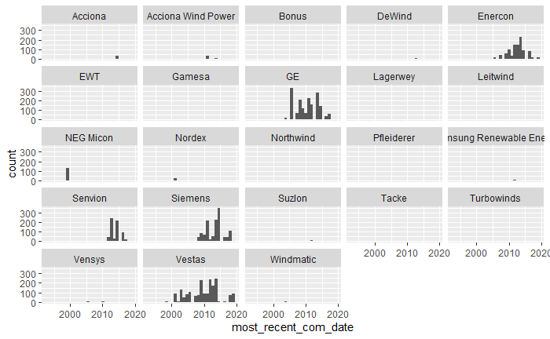

```r
plot_core <- ggplot(data = wind_turbine,
                    mapping = aes(x = most_recent_com_date)
                    )

plot_core + geom_histogram() +
  facet_wrap(~manufacturer)
```

```r
wind_turbine
```

| objectid | province_territory | project_name | total_project_capacity_mw | turbine_identifier | turbine_number | number_of_turbines_in_project | turbine_rated_capacity_k_w | rotor_diameter_m | hub_height_m | manufacturer | model | com_date_1 | com_date_2 | com_date_3 | latitude | longitude | notes | most_recent_com_date |
| --- | --- | --- | --- | --- | --- | --- | --- | --- | --- | --- | --- | --- | --- | --- | --- | --- | --- | --- |
| 1 | Alberta | Optimist Wind Energy | 0.90 | OWE1 | 1 | 2 | 150 | 23.0 | 30 | Bonus | AN 150/30 | 1993 | NA | NA | 49.52535 | -114.0548 | NA | 1993 |
| 2 | Alberta | Castle River Wind Farm | 44.00 | CRW1 | 1 | 60 | 600 | 44.0 | 40 | Vestas | V44/600 | 1997 | NA | NA | 49.51264 | -114.0357 | NA | 1997 |
| 3 | Alberta | Waterton Wind Turbines | 3.78 | WWT1 | 1 | 6 | 600 | 44.0 | 50 | Vestas | V44/600 | 1998 | NA | NA | 49.23307 | -113.6549 | NA | 1998 |
| 4 | Alberta | Waterton Wind Turbines | 3.78 | WWT2 | 2 | 6 | 600 | 44.0 | 50 | Vestas | V44/600 | 1998 | NA | NA | 49.23303 | -113.6302 | NA | 1998 |
| 5 | Alberta | Waterton Wind Turbines | 3.78 | WWT3 | 3 | 6 | 600 | 44.0 | 50 | Vestas | V44/600 | 1998 | NA | NA | 49.21755 | -113.6802 | NA | 1998 |
| 6 | Alberta | Waterton Wind Turbines | 3.78 | WWT4 | 4 | 6 | 660 | 47.0 | 50 | Vestas | V47/660 | 2000 | NA | NA | 49.21773 | -113.6579 | NA | 2000 |
| 7 | Alberta | Cowley North | 19.50 | CON1 | 1 | 15 | 1300 | 60.0 | 46 | Nordex | N60/1300 | 2001 | NA | NA | 49.56876 | -114.1104 | NA | 2001 |
| 8 | Alberta | Cowley North | 19.50 | CON2 | 2 | 15 | 1300 | 60.0 | 46 | Nordex | N60/1300 | 2001 | NA | NA | 49.56788 | -114.1097 | NA | 2001 |
| 9 | Alberta | Cowley North | 19.50 | CON3 | 3 | 15 | 1300 | 60.0 | 46 | Nordex | N60/1300 | 2001 | NA | NA | 49.56696 | -114.1103 | NA | 2001 |
| 10 | Alberta | Cowley North | 19.50 | CON4 | 4 | 15 | 1300 | 60.0 | 46 | Nordex | N60/1300 | 2001 | NA | NA | 49.56597 | -114.1105 | NA | 2001 |

[output cut: 990 more lines]

```r
# subset data for interest
wind_turbine_focus <- wind_turbine %>%
  select(turbine_rated_capacity_k_w, manufacturer, most_recent_com_date)

# identify top 5 manufacturers (by total number of wind turbines)
manufacturers <- wind_turbine_focus %>%
  group_by(manufacturer) %>%
  summarise(num_turbines = n()) %>%
  mutate(manu_ranking = min_rank(desc(num_turbines))) %>%
  arrange(desc(num_turbines))
num_top_manu <- 4
top_manu <- as_vector(manufacturers[1:num_top_manu, 'manufacturer'])

# group all manufacturers outside top 5 together
wind_turbine_focus <- wind_turbine_focus %>%
  mutate(manufacturer = replace(manufacturer, manufacturer %nin% top_manu, "Others"))

# add ranking for each manufacturer (based on total number of wind turbines)
wind_turbine_focus <- wind_turbine_focus %>%
  left_join(manufacturers) %>%
  select(-num_turbines) %>%
  mutate(manu_ranking = replace(manu_ranking, manufacturer == "Others", 6))
# for each year calculate the amount of capacity and number of turbines added
wind_turbine_focus <- wind_turbine_focus %>%
  group_by(most_recent_com_date) %>%
  mutate(annual_capacity_added = sum(turbine_rated_capacity_k_w, na.rm = TRUE),
         annual_turbines_added = n()
         ) %>%
  ungroup()

wind_turbine_focus
```

| turbine_rated_capacity_k_w | manufacturer | most_recent_com_date | manu_ranking | annual_capacity_added | annual_turbines_added |
| --- | --- | --- | --- | --- | --- |
| 150 | Others | 1993 | 6 | 300 | 2 |
| 600 | Vestas | 1997 | 1 | 600 | 1 |
| 600 | Vestas | 1998 | 1 | 1800 | 3 |
| 600 | Vestas | 1998 | 1 | 1800 | 3 |
| 600 | Vestas | 1998 | 1 | 1800 | 3 |
| 660 | Vestas | 2000 | 1 | 1320 | 2 |
| 1300 | Others | 2001 | 6 | 85820 | 109 |
| 1300 | Others | 2001 | 6 | 85820 | 109 |
| 1300 | Others | 2001 | 6 | 85820 | 109 |
| 1300 | Others | 2001 | 6 | 85820 | 109 |

[output cut: 990 more lines]

```r
# for each year calculate the proportion of turbines supplied and capacity added
# by each manufacturer
wind_turbine_focus <-  wind_turbine_focus %>%
  group_by(most_recent_com_date, manufacturer) %>%
  summarise(capacity_added = sum(turbine_rated_capacity_k_w, na.rm = TRUE),
            turbines_added = n(),
            prop_capacity_added = capacity_added / annual_capacity_added,
            prop_turbines_added = turbines_added / annual_turbines_added,
            annual_capacity_added = annual_capacity_added,
            annual_turbines_added = annual_turbines_added,
            manu_ranking = manu_ranking
            ) %>%
  distinct() %>%
  ungroup()
# confirm proportions sum to approx. 1 for each year
wind_turbine_focus %>%
  group_by(most_recent_com_date) %>%
  summarise(sum_prop_cap = sum(prop_capacity_added, na.rm = TRUE),
            sum_prop_turb = sum(prop_turbines_added, na.rm = TRUE))
```

| most_recent_com_date | sum_prop_cap | sum_prop_turb |
| --- | --- | --- |
| 1993 | 1 | 1 |
| 1995 | 1 | 1 |
| 1997 | 1 | 1 |
| 1998 | 1 | 1 |
| 1999 | 1 | 1 |
| 2000 | 1 | 1 |
| 2001 | 1 | 1 |
| 2002 | 1 | 1 |
| 2003 | 1 | 1 |
| 2004 | 1 | 1 |

[output cut: 15 more lines]

```r
count_NA_in_df(wind_turbine_focus)
```

| most_recent_com_date | manufacturer | capacity_added | turbines_added | prop_capacity_added | prop_turbines_added | annual_capacity_added | annual_turbines_added | manu_ranking |
| --- | --- | --- | --- | --- | --- | --- | --- | --- |
| 0 | 0 | 0 | 0 | 0 | 0 | 0 | 0 | 0 |

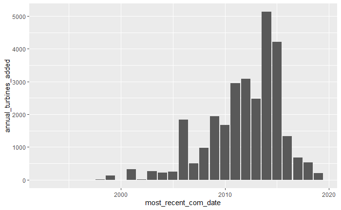

```r
# plot turbines added over time
p <- ggplot(data = wind_turbine_focus,
                 mapping = aes(x = most_recent_com_date,
                               y = annual_turbines_added)
                 )

p + geom_col()
```

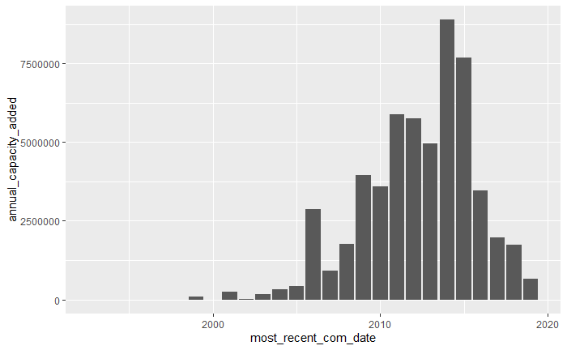

```r
# plot capacity added over time
p <- ggplot(data = wind_turbine_focus,
                 mapping = aes(x = most_recent_com_date,
                               y = annual_capacity_added)
                 )

p + geom_col()
```

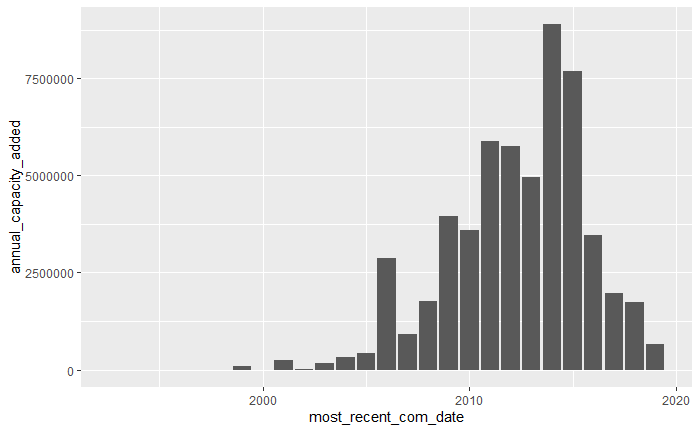

```r
# plot capacity added over time
p <- ggplot(data = wind_turbine_focus,
                 mapping = aes(x = most_recent_com_date,
                               y = annual_capacity_added)
                 )

p + geom_col()
```

```r
NA
NA
NA
NA
```

```r
min_year <- min(wind_turbine_focus$most_recent_com_date)
max_year <- max(wind_turbine_focus$most_recent_com_date)

x_limits = c(min_year, max_year)

# plot proportion of annual capacity added for each manufacturer over time
p_market_share <- ggplot(data = wind_turbine_focus,
                 mapping = aes(x = most_recent_com_date,
                               y = prop_capacity_added,
                               fill = reorder(manufacturer, manu_ranking))
                 )

p_market_share <- p_market_share + geom_col() +

  scale_x_continuous(limits = x_limits) +
  scale_y_continuous(labels = scales::percent) +
  scale_fill_brewer(palette = "Set3") +

  labs(x = "",
       y = "Market share",
       fill = "Manufacturer",
       title = "Shares of the Growing Canadian Wind Power Market by the Big Four Manufacturers",
       subtitle = "Data source: open.canada.ca") +

  theme_minimal()


# plot market growth
p_market_growth <- ggplot(data = wind_turbine_focus,
                          mapping = aes(x = most_recent_com_date,
                                        y = annual_capacity_added)
                 )
p_market_growth <- p_market_growth +

  geom_line(colour = "grey70", size = 1.5) +

  scale_x_continuous(limits = x_limits) +

  labs(x = "",
       y = paste("Total capacity commissioned (megawatts)"),
       caption = "Market share: the proportion of the total wind energy generation
       capacity commissioned in a given year") +

  theme_minimal()


  # +
  #facet_wrap(~ reorder(manufacturer, manu_ranking), ncol = 2)

# p + geom_line() +
#    facet_wrap(~ reorder(manufacturer, manu_ranking), ncol = 2) +
p_market <- cowplot::plot_grid(p_market_share, p_market_growth,
                     ncol = 1, rel_heights = c(3, 2),
                     align = 'v', axis = 'lr')
```

```
Removed 3 rows containing missing values (geom_col).
```

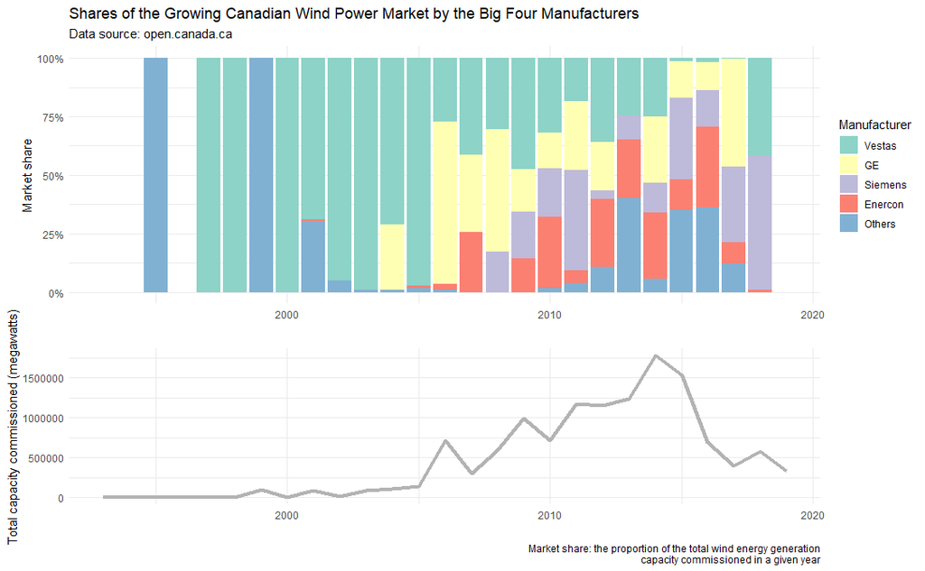

```r
p_market
```

```r
ggsave(plot = p_market,filename = "Shares_of_the_Canadian_wind_power_market.png")
```

```r
wind_turbine_focus
```

| most_recent_com_date | manufacturer | capacity_added | turbines_added | prop_capacity_added | prop_turbines_added | annual_capacity_added | annual_turbines_added | manu_ranking |
| --- | --- | --- | --- | --- | --- | --- | --- | --- |
| 1993 | Others | 300 | 2 | 1.000000000 | 1.000000000 | 300 | 2 | 6 |
| 1995 | Others | 600 | 1 | 1.000000000 | 1.000000000 | 600 | 1 | 6 |
| 1997 | Vestas | 600 | 1 | 1.000000000 | 1.000000000 | 600 | 1 | 1 |
| 1998 | Vestas | 1800 | 3 | 1.000000000 | 1.000000000 | 1800 | 3 | 1 |
| 1999 | Others | 99000 | 132 | 1.000000000 | 1.000000000 | 99000 | 132 | 6 |
| 2000 | Vestas | 1320 | 2 | 1.000000000 | 1.000000000 | 1320 | 2 | 1 |
| 2001 | Enercon | 600 | 1 | 0.006991377 | 0.009174312 | 85820 | 109 | 4 |
| 2001 | Others | 26000 | 20 | 0.302959683 | 0.183486239 | 85820 | 109 | 6 |
| 2001 | Vestas | 59220 | 88 | 0.690048940 | 0.807339450 | 85820 | 109 | 1 |
| 2002 | Others | 600 | 1 | 0.049751244 | 0.125000000 | 12060 | 8 | 6 |

[output cut: 67 more lines]

```r
market_share_binned <- wind_turbine_focus %>%
  filter(most_recent_com_date <= 2017) %>%
  mutate(bin = cut_width(most_recent_com_date, width = 1)) %>%
  group_by(bin, manufacturer) %>%
  summarise(total_capacity_added = sum(capacity_added),
            manu_ranking = manu_ranking) %>%
  distinct()
market_share_binned
```

| bin | manufacturer | total_capacity_added | manu_ranking |
| --- | --- | --- | --- |
| [1992.5,1993.5] | Others | 300 | 6 |
| (1994.5,1995.5] | Others | 600 | 6 |
| (1996.5,1997.5] | Vestas | 600 | 1 |
| (1997.5,1998.5] | Vestas | 1800 | 1 |
| (1998.5,1999.5] | Others | 99000 | 6 |
| (1999.5,2000.5] | Vestas | 1320 | 1 |
| (2000.5,2001.5] | Enercon | 600 | 4 |
| (2000.5,2001.5] | Others | 26000 | 6 |
| (2000.5,2001.5] | Vestas | 59220 | 1 |
| (2001.5,2002.5] | Others | 600 | 6 |

[output cut: 62 more lines]

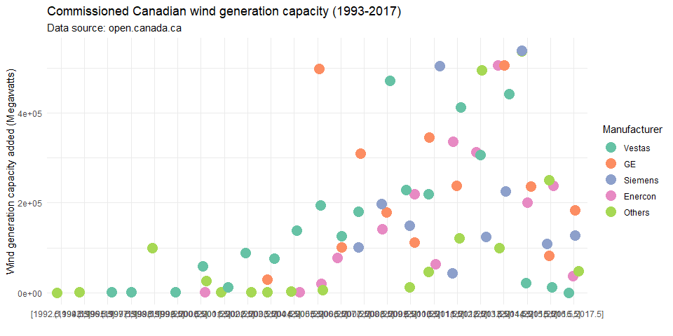

```r
p_market_share_3 <- ggplot(data = market_share_binned,
                           mapping = aes(x = bin,
                                         y = total_capacity_added,
                                         colour = reorder(manufacturer, manu_ranking)
                                         )
                           )


p_market_share_3 <- p_market_share_3 + geom_jitter(size = 5, width = 0.25) +

  #geom_line(mapping = aes(group = reorder(manufacturer, manu_ranking))) +

  # scale_x_continuous(limits = x_limits) +
  scale_colour_brewer(palette = "Set2") +
  #scale_x_discrete(labels = c("1993-1997", "1998-2002", "2003-2007", "2008-2012", "2013-2017")) +

  labs(x = "",
       y = "Wind generation capacity added (Megawatts)",
       colour = "Manufacturer",
       title = "Commissioned Canadian wind generation capacity (1993-2017)",
       subtitle = "Data source: open.canada.ca") +

  theme_minimal()

p_market_share_3
```

```r
ggsave(plot = p_market_share_3,filename = "Commissioned Canadian wind generation capacity (1993-2017) 1.png")
```

[figure not shown]

```r
p_market_share_4 <- ggplot(data = market_share_binned,
                           mapping = aes(x = bin,
                                         y = total_capacity_added,
                                         fill = reorder(manufacturer, manu_ranking)
                                         )
                           )


p_market_share_4 <- p_market_share_4 + geom_col(position = position_dodge(preserve = "single")) +

  #geom_line(mapping = aes(group = reorder(manufacturer, manu_ranking))) +

  # scale_x_continuous(limits = x_limits) +
  scale_fill_brewer(palette = "Set2") +
  #scale_x_discrete(labels = c("1993-1997", "1998-2002", "2003-2007", "2008-2012", "2013-2017", "2018 - ")) +

  labs(x = "",
       y = "Wind generation capacity added (Megawatts)",
       fill = "Manufacturer",
       title = "Commissioned Canadian wind generation capacity (1993-2019)",
       subtitle = "Data source: open.canada.ca") +

  theme_minimal()

p_market_share_4
```

```r
ggsave(plot = p_market_share_4,filename = "Commissioned Canadian wind generation capacity (1993-2017) 2.png")
```

[figure not shown]

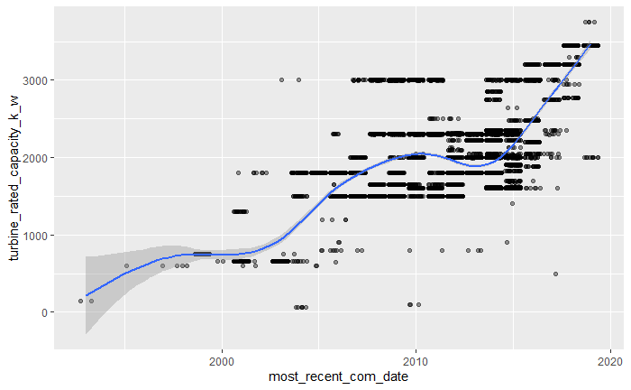

```r
plot_core <- ggplot(data = wind_turbine,
                    mapping = aes(x = most_recent_com_date,
                                  y = turbine_rated_capacity_k_w)
                    )

plot_core + geom_jitter(alpha = 0.4) + geom_smooth()
```

could look at capacity added per year

```r
wind_turbine %>%
  group_by(most_recent_com_date) %>%
  summarise(mean(number_of_turbines_in_project, na.rm = TRUE))
```

| most_recent_com_date | mean(number_of_turbines_in_project, na.rm = TRUE) |
| --- | --- |
| 1993 | 2.00000 |
| 1995 | 1.00000 |
| 1997 | 60.00000 |
| 1998 | 6.00000 |
| 1999 | 67.22727 |
| 2000 | 4.00000 |
| 2001 | 39.73394 |
| 2002 | 11.62500 |
| 2003 | 101.27273 |
| 2004 | 38.98649 |

[output cut: 15 more lines]